# USW Computational Basics - Skriptum

Wir schreiben:

`df[df[NameDerSpalte] < Mindestwert]`

```python
df[df["Healthy life expectancy at birth"] < 40]
```

|  | country | year | Life Ladder | Log GDP per capita | Social support | Healthy life expectancy at birth | Freedom to make life choices | Generosity | Perceptions of corruption | Positive affect | Negative affect | Confidence in national government | Democratic Quality | Delivery Quality | Standard deviation of ladder by country-year | Standard deviation/Mean of ladder by country-year | GINI index (World Bank estimate) | GINI index (World Bank estimate), average 2000-15 | gini of household income reported in Gallup, by wp5-year |
| --- | --- | --- | --- | --- | --- | --- | --- | --- | --- | --- | --- | --- | --- | --- | --- | --- | --- | --- | --- |
| 248 | Central African Republic | 2007 | 4.160130 | 6.761289 | 0.532297 | 38.385059 | 0.662871 | 0.099451 | 0.782131 | 0.567980 | 0.329995 | 0.623566 | -1.468937 | -1.397169 | 1.656170 | 0.398105 | NaN | 0.499 | NaN |
| 1207 | Sierra Leone | 2006 | 3.628185 | 6.975739 | 0.561356 | 37.766476 | 0.679001 | 0.113010 | 0.836166 | 0.505072 | 0.380655 | 0.541412 | -0.314346 | -1.065230 | 1.819301 | 0.501436 | NaN | 0.371 | NaN |
| 1208 | Sierra Leone | 2007 | 3.585127 | 7.025132 | 0.686471 | 38.560307 | 0.720373 | 0.259907 | 0.830483 | 0.581781 | 0.289842 | 0.561873 | -0.139665 | -1.031073 | 1.793122 | 0.500156 | NaN | 0.371 | NaN |
| 1209 | Sierra Leone | 2008 | 2.997251 | 7.053099 | 0.590737 | 39.351990 | 0.716396 | 0.160101 | 0.924901 | 0.533604 | 0.369601 | 0.687578 | -0.189854 | -1.007436 | 1.688531 | 0.563360 | NaN | 0.371 | NaN |
| 1550 | Zimbabwe | 2006 | 3.826268 | 7.366704 | 0.821656 | 39.087681 | 0.431110 | -0.053216 | 0.904757 | 0.715229 | 0.297147 | 0.317073 | -1.236102 | -1.570760 | 2.013538 | 0.526241 | NaN | 0.432 | NaN |

```python
df[df["year"] == 2017].head()
```

|  | country | year | Life Ladder | Log GDP per capita | Social support | Healthy life expectancy at birth | Freedom to make life choices | Generosity | Perceptions of corruption | Positive affect | Negative affect | Confidence in national government | Democratic Quality | Delivery Quality | Standard deviation of ladder by country-year | Standard deviation/Mean of ladder by country-year | GINI index (World Bank estimate) | GINI index (World Bank estimate), average 2000-15 | gini of household income reported in Gallup, by wp5-year |
| --- | --- | --- | --- | --- | --- | --- | --- | --- | --- | --- | --- | --- | --- | --- | --- | --- | --- | --- | --- |
| 9 | Afghanistan | 2017 | 2.661718 | 7.460144 | 0.490880 | 52.339527 | 0.427011 | -0.106340 | 0.954393 | 0.496349 | 0.371326 | 0.261179 | NaN | NaN | 1.454051 | 0.546283 | NaN | NaN | 0.286599 |
| 19 | Albania | 2017 | 4.639548 | 9.373718 | 0.637698 | 69.051659 | 0.749611 | -0.035140 | 0.876135 | 0.669241 | 0.333884 | 0.457738 | NaN | NaN | 2.682105 | 0.578096 | NaN | 0.303250 | 0.410488 |
| 25 | Algeria | 2017 | 5.248912 | 9.540244 | 0.806754 | 65.699188 | 0.436670 | -0.194670 | 0.699774 | 0.641980 | 0.288710 | NaN | NaN | NaN | 2.039765 | 0.388607 | NaN | 0.276000 | 0.527556 |
| 41 | Argentina | 2017 | 6.039330 | 9.843519 | 0.906699 | 67.538704 | 0.831966 | -0.186300 | 0.841052 | 0.809423 | 0.291717 | 0.305430 | NaN | NaN | 2.409329 | 0.398940 | NaN | 0.476067 | 0.394176 |
| 53 | Armenia | 2017 | 4.287736 | 9.034711 | 0.697925 | 65.125687 | 0.613697 | -0.132166 | 0.864683 | 0.625014 | 0.437149 | 0.246901 | NaN | NaN | 2.325379 | 0.542333 | NaN | 0.325067 | 0.478877 |

Oft ist es auch sinnvoll Visualisierungen zu verwenden, um die Daten darzustellen. Wir könnten uns beispielweise den [GINI Index](https://de.wikipedia.org/wiki/Gini-Koeffizient) als Histogramm anzeigen lassen:

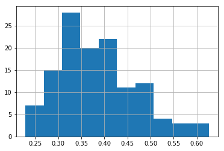

```python
df[df["year"] == 2017]['GINI index (World Bank estimate), average 2000-15'].hist()
```

Um Zusammenhänge und Korrelationen festzustellen kann man Scatterplots verwenden. Damit ist es möglich einen Wert auf der y-Achse und einen auf der x-Achse aufzutragen. Wenn eine Punktwolke ensteht gibt es keinen Zusammenhang zwischen diesen Größen. Je eher die Verteilung einer Geraden gleicht, um so stärker ist der Zusammenhang.

Betrachten wir den Zusammenhang zwischen BIP/Person und Lebenserwartung einerseits und den Zusammenhang zwischen "Social Support" und Lebenserwartung andererseits.

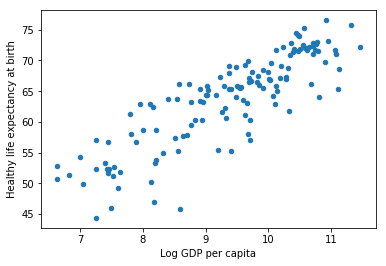

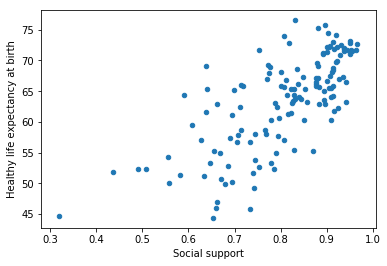

```python
df[df["year"] == 2017].plot.scatter(x="Log GDP per capita", y = "Healthy life expectancy at birth")

df[df["year"] == 2017].plot.scatter(x="Social support", y = "Healthy life expectancy at birth")
```

Natürlich braucht man nicht für jede Analysie den kompletten Datensatz. Für genauere Betrachtungen macht es Sinn die Daten einzuschränken. Wir könnten also nur Deutschland, Österreich und die Schweiz betrachten.

Zuerst sehen wir uns den Mittelwert der Korruption für diese Länder über alle Jahre hinweg an. Dazu benutzen wir den Befehl `mean()` und schreiben das Ergebnis direkt mit `print` auf den Bildschirm.

```python
print("Corruption Austria:    ",df[df["country"]=="Austria"]["Perceptions of corruption"].mean())
print("Corruption Germany:    ",df[df["country"]=="Germany"]["Perceptions of corruption"].mean())
print("Corruption Switzerland:",df[df["country"]=="Switzerland"]["Perceptions of corruption"].mean())
```

```
Corruption Austria:     0.596848064661026
Corruption Germany:     0.614804724852244
Corruption Switzerland: 0.3119955360889435
```

Da wir uns auf drei Länder eingeschränkt haben, können wir nun auch detaillierte Analysen durchführen, ohne dass das Ergebnis unübersichtlich wird. Anstelle des Mittelwertes, können wir also den zeitlichen Verlauf des Korruptionsindex betrachten.

Dazu benutzen wir den `plot` Befehl von pandas, der ein wenig anders aufgebaut ist, als der von matplotlib. Als x und y übergibt man Beispielweise keine Liste, sondern nur den Namen der Spalte, unter der man die relevanten Datenpunkte findet. Außerdem erstellt dieser Befehl immer eine neue Achse. Um dieses Verhalten zu unterdrücken, damit wir alle Daten in einer Figur sehen, müssen wir der Achse einen Namen geben, sobald sie erstellt wird (ax1) und allen weiteren Plotbefehlen mit `ax=ax1` sagen, dass sie die existierende Achse weiterverwenden sollen.

```
Text(0.5,1,'Perceptions of corruption')
```

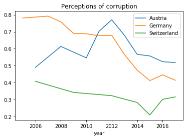

```python
ax1=df[df["country"]=="Austria"].plot(x="year",y="Perceptions of corruption",label="Austria")
df[df["country"]=="Germany"].plot(x="year",y="Perceptions of corruption",label="Germany",ax=ax1)
df[df["country"]=="Switzerland"].plot(x="year",y="Perceptions of corruption",label="Switzerland",ax=ax1)
plt.title("Perceptions of corruption")
```

Pandas bietet natürlich noch viele weitere Möglichkeiten um Daten zu analysierenm zu verarbeiten und aufzubereiten. Eine vollständige Übersicht findet man im [Pandas User Guide](https://pandas.pydata.org/pandas-docs/stable/user_guide/index.html).

## Zusammenfassung

### Daten Einlesen mit Pandas

Pandas kann eine Vielzahl von Datentypen einlesen und in Dataframes konvertieren. Die wichtigsten Befehle dazu sind `pd.read_excel` und `pd.read_csv`.

### Auswählen von Einträgen mit gewissen Eigenschaften

Man kann einen Dataframe auf Zeilen mit gewissen Eigenschaften einschränken, indem man

`df[df[spaltenname]==wert]`

benutzt. Analog funktionert das auch mit <= und >=.

Um nicht die ganze Zeile auszuwälen, sondern nur den Eintrag in einer gewissen Spalte schreibt man

`df[df[spaltenname]==wert][spaltenname2]`

### Plotten mit Pandas

Um Daten mit Pandas zu visualisieren gibt es viele Möglichkeiten:

- Histograme (`df.hist()`)
- Scatterplots (`df.plot.scatter(x = spalte1,y = spalte2)`)
- Linienplots (`df.plot(x = spalte1,y = spalte2)`)

## Kapitel 15 - Analytisch Differenzieren und Integrieren mit dem Paket `sympy`

Bisher haben wir mit Python immer numerische Berechnungen durchgeführt. Das heißt, alle Differentiale wurden vom Computer als kleine Differenzen genähert und irrationale Zahlen, wie zum Beispiel Wurzeln wurden schlichtweg gerundet. Das ist zwar die einfachste Art, wie ein Computer Mathematik betreiben kann, nicht aber die einzige. Mit Python ist es auch möglich, mathematische Probleme analytisch zu lösen, also so, wie sie ein Mensch lösen würde. So können wir Stammfunktionen berechnen, Gleichungen auflösen und komplexe mathematische Probleme lösen, für die ein Mensch Tage brauchen würde.

Fangen wir an, indem wir den Unterschied zwischen numerischen und analytischen Berechnungen genauer betrachten. Als Beispiel soll ein einfacher Prozess, das Ziehen einer Quadratwurzel, dienen. Berechnen wir die Wurzel aus 9 mit dem Standard-Mathematikpaket `math`.

```python
import math
math.sqrt(9)
```

```
3.0
```

Das funktioniert problemlos, ganz genau gleich wie bei jedem Taschenrechner. Wie wir alle wissen, ist die Wurzel aus 9 exakt 3, denn 3 mal 3 ist 9. Hier muss nicht gerundet werden und wir können mit unserem Ergebnis zufrieden sein. Was aber, wenn wir an der Wurzel aus 8 interessiert sind, die bekannterweise keine ganzzahlige Lösung besitzt?

```python
import math
math.sqrt(8)
```

```
2.8284271247461903
```

Hier bekommen wir zwar eine näherungsweise Lösung, korrekt ist dieses Ergebnis aber nicht mehr. Die Wurzel aus 8 ist nicht exakt 2.8284271247461903, es würden noch unendlich viele Nachkommastellen folgen. Wieso kann das ein Problem werden? Versuchen wir einmal die Wurzel aus 8 mit der Wurzel aus 8 zu multiplizieren. Wir (als Menschen) müssen die Wurzel aus 8 dazu nicht kennen, wir wissen ja, dass die Wurzel aus 8 mal der Wurzel aus 8 wieder 8 sein muss.

$$\sqrt{8}*\sqrt{8}=\sqrt{8*8}=\sqrt{8^2}=8 $$

Wurzel und Quadrat heben sich sozusagen auf. Wenn wir diesen Zusammenhang schon verstehen, ohne überhaupt im Kopf die Wurzel ziehen zu können, dann sollte ein Computer mit dieser Aufgabe doch auch kein Problem haben, oder?

```python
import math
math.sqrt(8) * math.sqrt(8)
```

```
8.000000000000002
```

Scheinbar doch. Python behauptet felsenfest, dass die Wurzel aus 8 zum Quadrat ein bisschen größer ist als 8. Der Fehler ist klein, aber man muss ihn ernst nehmen. In einem umfangreichen Programm werden solche Berechnungen nämlich sehr oft hintereinander ausgeführt, und der Fehler schaukelt sich auf. Und solche Fehler entstehen natürlich nicht nur beim Wurzel ziehen, sondern bei jeder Operation, die in irgendeiner Form runden muss. Schon die Zahl 1/3 kann nicht mehr exakt gespeichert werden, da man für die Darstellung als 0.33333333333..... unendlich viele Stellen bräuchte um exakt zu sein.

Wie kann man dieses Problem lösen? Mit analytischen Berechnungen! Wenn Python verstehen würde, was 1/3 bedeutet, also nicht nur eine Zahl mit endlich vielen Stellen, sondern die Rechenoperation, die die Zahl 1 in 3 gleich große Teile teilt, wären wir nicht mehr auf Runden angewiesen. Noch schöner wäre es, wenn Python auch die Operation des Wurzelziehens verstehen würde, sodass das Quadrat einer Wurzel automatisch immer wieder die Zahl selbst ergeben würde. All das, und noch viel mehr ist möglich, mit dem Python-Paket `sympy`.

Wir sehen uns dieses Paket im Folgenden genauer an und benutzen es als erstes, um damit eine Wurzel zu ziehen:

```python
import sympy
sympy.sqrt(9)
```

```
3
```

Unser erstes erfreuliches Ergebnis: Die Wurzel aus 9 ist nach wie vor 3. Was passiert aber mit der Wurzel aus 8?

```python
import sympy
sympy.sqrt(8)
```

```
2*sqrt(2)
```

Dieses Ergebnis sieht zwar sonderbar aus, ist aber absolut korrekt. Die Wurzel aus 8 ist exakt doppelt so groß wie die Wurzel aus 2.

Für Mathematiker: $\sqrt{8}=\sqrt{4*2}=\sqrt{4}*\sqrt{2}=2*\sqrt{2}$

Der Vorteil, den wir hier haben ist offensichtlich: Dieses Ergebnis ist exakt, wir müssen nicht runden. Und wenn wir wollen, können wir das Ergebnis immer noch in eine Dezimalzahl umrechnen:

```python
import sympy
float(sympy.sqrt(8))
```

```
2.8284271247461903
```

Nun könnten wir noch überprüfen, ob das Quadrieren einer Wurzel so besser funktioniert:

```python
import sympy
sympy.sqrt(8) * sympy.sqrt(8)
```

```
8
```

Offensichtlich. Der Vorteil dieser Berechnung ist noch gering, denn die Wurzel aus 8 kann man auch im Kopf umformen (siehe die Berechnung weiter oben). Hier kommt dann aber der Vorteil eines Computers zum Tragen: Wenn das Prinzip funktioniert, sind kompliziertere Berechnungen nicht wirklich schwieriger als einfache Berechnungen, wie folgendes Beispiel zeigt:

```python
import sympy
sympy.sqrt(1264)
```

```
4*sqrt(79)
```

### Symbolisches Programmieren

Die Wurzel aus 1264 ist also 4 mal die Wurzel aus 79. Auch mit viel Übung kann man solche Berechnungen nicht ohne weiteres im Kopf durchführen. Das Paket`sympy` kann das - und noch viel mehr. Besonders spannend wird es, wenn wir selbst Variablen definieren. Dafür gibt es den Befehl `symbols`, der Python erklärt, dass es sich bei diesen Variablen um allgemeine Variablen handelt, in denen kein Wert gespeichert ist. Trotzdem kann Python damit rechnen. Wir können einen Ausdruck speichern, der x und y beinhaltet und Python kann damit arbeiten, obwohl wir x und y keine Werte zugewiesen haben, sondern sie nur als allgemeine **Symbole** verwenden:

```python
from sympy import *
x = symbols("x")
y = symbols("y")
ausdruck = 3 * x - 4 * y
ausdruck
```

```
3*x - 4*y
```

```python
ausdruck - 1
```

```
3*x - 4*y - 1
```

```python
ausdruck + 3 * y
```

```
3*x - y
```

```python
ausdruck * x # die Lösung wird hier noch nicht ausmultipliziert
```

```
x*(3*x - 4*y)
```

```python
expand(ausdruck * x) # expand führt die Mutliplikation aus
```

```
3*x**2 - 4*x*y
```

Man sieht sofort: Python versteht nun wirklich die Rechenoperationen, und obwohl der Variablen x kein Wert zugeordnet wurde, ist klar, dass x mal x das gleiche ist wie x-Quadrat. Das können wir zum Beispiel nutzen um sehr komplizierte Ausdrücke mit dem Befehl `factor` zu vereinfachen:

```python
from sympy import *
x = symbols("x")
y = symbols("y")
z = symbols("z")
ausdruck = -x * y * z**2 + 2 * x * y * z - x * z**2 + 2 * x * z + y * z**2 - 2 * y * z + z**2 - 2 * z
factor(ausdruck)
```

```
-z*(x - 1)*(y + 1)*(z - 2)
```

Der ausgeprochen komplizierte Ausdruck

`-x * y * z**2 + 2 * x * y * z - x * z**2 + 2 * x * z + y * z**2 - 2 * y * z + z**2 - 2 * z`

lässt sich also kompakt schreiben als

`-z*(x - 1)*(y + 1)*(z - 2)`

Das ist zwar hilfreich, in der Praxis wird man aber sehr selten in die Situation kommen, solche Vereinfachungen durchführen zu müssen (außer vielleicht im Rahmen von Mathematiklehrveranstaltungen). Viel öfter möchte man zum Beispiel Gleichungen lösen.

### Lösen von Gleichungen

Während zur Lösung quadratischer Gleichungen noch Formeln bereitstehen, sind Gleichungen 3-ter Ordnung, wie beispielsweise

$$3x^3+x^2-x=0 $$

auf dem Papier ungleich schwerer zu lösen. Schneller geht es mit dem `sympy`-Befehl `solve`. Dieser Befehl benötigt nur die Gleichung und als zweites Argument die Variable, die ausgerechnet werden soll:

```python
from sympy import *

x = symbols("x")
solve(3 * x**3 + x**2 - x , x)
```

```
[0, -1/6 + sqrt(13)/6, -sqrt(13)/6 - 1/6]
```

Die drei Lösungen der Gleichung $3x^3+x^2-x=0 $ sind also $x=0$, $x=-\frac{1}{6} + \frac{\sqrt{13}}{6}$ und $x=-\frac{1}{6} - \frac{\sqrt{13}}{6}$

### Differenzieren und Integrieren

Seinen größten Vorteil aus der Perspektive der Systemwissenschaften spielt `sympy` beim Berechnen von Differentialen und Integralen aus. Das numerische Differenzieren und Integrieren haben wir bereits in früheren Kapiteln besprochen. Die Lösungen dort waren allerdings immer Zahlen oder Listen von Zahlen. Allgemeine, analytische Erkenntnisse, wie die, dass das Integral von $\cos{(x)}$ exakt $\sin{(x)}$ ist, konnten wir so nicht gewinnen. Mit Hilfe von sympy's `diff` und `integrate` Befehlen können wir auch sehr komplizierte Ableitungen und Integrale analytisch durchführen und bekommen als Lösungen keine Zahlen, sondern vollständige, allgemein gültige Funktionen:

```python
from sympy import *

x = symbols("x")
```

```python
diff(sin(x))
```

```
cos(x)
```

```python
integrate(cos(x))
```

```
sin(x)
```

```python
diff(sin(3 * x) * x**2)
```

```
3*x**2*cos(3*x) + 2*x*sin(3*x)
```

```python
integrate(sin(x) * cos(x))
```

```
sin(x)**2/2
```

```python
diff(x**3 + log(x) * sin(x) + exp(x**2))
```

```
3*x**2 + 2*x*exp(x**2) + log(x)*cos(x) + sin(x)/x
```

Aber Achtung: Integrale, die analytisch nicht lösbar sind, kann auch Python nicht lösen. Differenzieren läuft immer nach sehr simplen Regeln ab, und prinzipiell kann man mit diesen Regeln jede Funktion ableiten. Integrieren ist jedoch mehr ein kreativer Prozess, und hierbei können Zusammenhänge auftauchen, die sich einfach nicht berechnen lassen. Das hat nichts damit zu tun, dass die richtigen "Rechenregeln" nur einfach noch nicht gefunden wurden. Es ist vielmehr eine Eigenschaft der Integralrechnung selbst. Unlösbaren Integrale müssen nicht schrecklich kompliziert sein. Schon das einfache Beispiel $\frac{\sin(x)}{\log(x)}$ ist nicht mehr integrierbar:

```python
integrate(sin(x) / log(x))
```

```
Integral(sin(x)/log(x), x)
```

Wenn die obige Zelle ausgeführt wird, zeigt sich, dass Python eine Zeitlang rechnet und offensichtlich versucht das Integral zu lösen. Wenn allerdings keine partielle Integration, keine Substitutionen oder andere Tricks mehr weiterhelfen, kapituliert Python (und auch jegliche andere Mathematik-Software und das menschliche Hirn). Als Lösung bekommt man dann die Aussage:

$$\int \frac{\sin(x)}{\log(x)} dx = \int \frac{\sin(x)}{\log(x)} dx $$

Das ist natürlich (per Definition) nicht falsch, bringt uns aber auch nicht wirklich weiter. Wenn wir dieses Integral in einem bestimmten Bereich lösen wollen, sind wir wieder auf numerische Methoden angewiesen. Diese liefern zwar keine schönen Funktionen, sondern immer nur gerundete Zahlen. Dafür funktionieren sie aber wirklich immer. Man sieht also, dass sowohl numerische, als auch analytische Methoden ihre Daseinsberechtigung haben, und man sich je nach Problem für eine der beiden Herangehensweisen entscheiden sollte. Gerade im mathematischen Bereich hat das Arbeiten mit analytischen Funktionen große Vorteile.

Die Anwedungsgebiete von `sympy` enden aber nicht mit Differenzieren und Integrieren. Man kann damit auch Grenzwerte berechnen, Differentialgleichungen lösen, Eigenwerte und Eigenvektoren ausrechnen oder (wenn man das wirklich möchte ;-) eine Bessel-Funktion in eine sphärische Bessel-Funktion transformieren.

### Rechnen mit Matritzen

`Sympy` erlaubt es zum Beispiel auch mit Matrizen zu rechnen. Alle wichtigen Rechenoperationen werden unterstützt. Matrizen werden in eckigen Klammer geschrieben, wobei jede Zeile ihrerseits in eckige Klammern gesetzt wird. `Sympy` betrachtet Matritzen also eigentlich als Listen von Listen. Die Matrix

$$M=\left(\begin{array}{ccc}1&3&2\\1&1&1\\2&3&1\end{array}\right) $$

kann demnach geschrieben werden als:

```python
M = Matrix([[1,3,2],[1,1,1],[2,3,1]])
M
```

```
Matrix([
[1, 3, 2],
[1, 1, 1],
[2, 3, 1]])
```

Grundrechenarten funktionieren ganz intuitiv mit den dazugehörigen Operatoren +, * und -:

```python
M + M
```

```
Matrix([
[2, 6, 4],
[2, 2, 2],
[4, 6, 2]])
```

```python
3 * M
```

```
Matrix([
[3, 9, 6],
[3, 3, 3],
[6, 9, 3]])
```

```python
M - M
```

```
Matrix([
[0, 0, 0],
[0, 0, 0],
[0, 0, 0]])
```

Auch die (per Hand oft langwierige) Matrix-Multiplikation lässt sich mit `sympy` einfach handhaben.

```python
M = Matrix([[1,3,2],[1,1,1],[2,3,1]])
N = Matrix([[4,1,2],[1,2,1],[1,2,4]])

M * N
```

```
Matrix([
[ 9, 11, 13],
[ 6,  5,  7],
[12, 10, 11]])
```

```python
N * M
```

```
Matrix([
[ 9, 19, 11],
[ 5,  8,  5],
[11, 17,  8]])
```

Als schnelle Überprüfung, ob es sich wirklich um eine echte Matrixmultiplikation handelt, und nicht einfach nur die Elemente miteinander multipliziert werden, kann man `M * N` ausrechnen lassen, und das Ergebnis mit `N * M` vergleichen. In unserem Beispiel sehen wir, dass `M * N` nicht das gleiche ist wie `N * M`, ganz so wie es sich für Matrixmultiplikationen gehört.

Aber auch erweiterte Rechenoperationen sind möglich. Beispielsweise das Berechnen von Determinanten, welches unter anderem zum Lösen von Gleichungssystemen mit der Cramerschen Regel (https://de.wikipedia.org/wiki/Cramersche_Regel) benötigt wird:

```python
M.det()
```

```
3
```

Auch das Berechnen von Eigenwerten ist möglich:

```python
M.eigenvals()
```

```
{-1: 1, -sqrt(7) + 2: 1, 2 + sqrt(7): 1}
```

## Zusammenfassung

Das Paket `sympy` ermöglicht es mit Python analytische Berechnungen durchzuführen. Das hat den Vorteil, dass Zahlen nicht gerundet werden, sondern Brüche oder Wurzeln exakt verwendet werden können. So werden nicht nur Rundungsfehler verhindert, sondern viele Rechenoperationen möglich, die numerisch nicht, oder nur näherungsweise gelingen.

### Lösen von Gleichungen

Das Lösen von Gleichungen erfordert numerisch in der Regel Tricks und Kreativität. Mit `sympy` lassen sich Gleichungen aber exakt lösen. Symbole, die in diesen Gleichungen vorkommen, werden zunächst mit dem Befehl `symbols` definiert und sodann mit dem Befehl `solve(gleichung, variable)` einer Lösung nach der gesuchten Variablen zugeführt.

### Differenzieren

Die Ableitung einer Funktion wird mit `diff` berechnet, wobei auch hier die vorkommenden Variablen zuvor mit `symbols` zu deklarieren sind.

### Integrieren

Das Integrieren, also das Suchen der Stammfunktion, geschieht mit dem Befehl `integrate`.

**Merke**: Nicht alle Funktionen können analytisch integriert werden. Für viele existiert keine analytische Lösung. Für solche Probleme muss auf numerische Methoden zurückgegriffen werden. Diese benötigen zwar längere Rechenzeit und liefern Lösungen nur näherungsweise und in bestimmten Intervallen. Dafür funktionieren sie in der Regel immer.

# Kapitel 16 - Netzwerke

Eine besonders fruchtbare Form, die Komponenten eines Systems in ihren Wechselwirkungen zu untersuchen, bietet die Netzwerkforschung. Ähnlich wie die Systemwissenschaft findet die Netzwerkforschung ihren Gegenstand in unterschiedlichsten Bereichen. Computer, die miteinander kommunizieren, bilden Computernetzwerke. Menschen, die miteinander in Beziehung stehen, bilden soziale Netzwerke. Tiere und Pflanzen, die sich einen Lebensraum teilen, bilden ökologische Netzwerke. All diese Netzwerke, obwohl sie eigentlich grundverschieden scheinen, haben gemeinsame Eigenschaften und folgen ähnlichen Regeln.

In den letzten Jahren gewinnt der Netzwerkbegriff in den Wissenschaften enorm an Bedeutung. Es ist deshalb kaum verwunderlich, dass auch Python mittlerweile spezialisierte Pakete bereithält, die sich der Darstellung und Analyse von Netzwerken widmen. Wir werden uns im Folgenden eines dieser Paket etwas genauer ansehen.

### Was sind Netzwerke?

Von Netzwerken spricht man immer dann, wenn Objekte als **Knoten** (oder auf Englisch auch **nodes** oder **vertices**) vorliegen, die mit anderen solchen Objekten in irgendeiner Weise verbunden sind. Die **Verbindungen** werden im Englischen **links** oder auch **edges** genannt.

Charakterisiert werden Netzwerke durch ihre Verbindungsstruktur, also durch die Information darüber, welche Knoten mit welchen anderen Knoten auf welche Weise verbunden sind. Aus dieser Verbindungsstruktur ergibt sich eine Vielzahl unterschiedlicher Netzwerktypen, von denen wir einige weiter unten detaillierter besprechen.

### NetworkX

Zunächst sehen wir uns nun aber einige Grundlagen des Python-Pakets `NetworkX` an, das auf die Darstellung und Analyse von Netzwerken spezialisiert ist und bereits im installierten Anaconda-Paket enthalten ist.

Für den Anfang betrachten wir ein sehr einfaches Netzwerk: Das Netzwerk soll aus drei Personen bestehen: Alice, Bob und Carol. Diese drei Personen sind die Knoten (*nodes*) unseres Netzwerks. Alle sind miteinander befreundet, was wir in unserem "Freundschaftsnetzwerk" durch Verbindungen (*edges*) darstellen.

Wir beginnen damit, das Paket `NetworkX` zu importieren und zunächst ein leeres Netzwerk anzulegen. Dieses füllen wir sodann mit *nodes* und *edges*:

```python
import networkx as nx

G = nx.Graph() # erstelle ein neues Netzwerk mit dem Namen G
```

Im nächsten Schritt fügen wir drei Knoten hinzu: Alice, Bob und Carol.

```python
G.add_node("Alice") # füge dem Netzwerk G den Knoten "Alice" hinzu
G.add_node("Bob")
G.add_node("Carol")
```

Um das Netzwerk grafisch darzustellen, benötigen wir abermals das Paket `matplotlib`, das sehr gut mit `networkx` harmoniert.

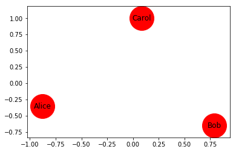

```python
import matplotlib.pyplot as plt
%matplotlib inline

nx.draw_networkx(G, node_size = 1600) # zeichne das Netzwerk G. Die Knoten sollen die Größe 1600 haben.
```

Wir sehen: die Knoten werden korrekt dargestellt. Was noch fehlt, sind die Verbindungslinien zwischen den Knoten. Diese werden mit dem Befehl `G.add_edge(von, zu)` hinzugefügt:

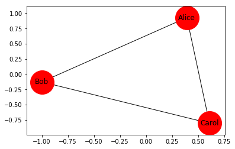

```python
G.add_edge("Alice","Bob") # füge dem Netzwerk G eine neue Verbindung zwischen Alice und Bob hinzu.
G.add_edge("Bob","Carol")
G.add_edge("Carol","Alice")

nx.draw_networkx(G, node_size = 1600)
```

Somit ist unser (sehr einfaches) Netzwerk korrekt dargestellt. Wenn wir die obige Code-Zelle mehrmals ausführen, fällt auf, dass die Positionen der einzelnen Knoten jedesmal neu vergeben werden. Sie werden zufällig generiert. In dieser Darstellung haben sie keine Bedeutung, wichtig ist nur, wer mit wem verbunden ist, nicht an welchem Ort sie sich befinden.

Fügen wir unserem Netzwerk eine weitere Person hinzu: Dan. Dan ist nur mit Carol befreundet, kennt sonst aber niemanden aus dem Netzwerk. Wir machen also nur eine Verbindung zwischen Carol und Dan:

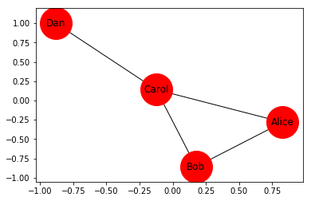

```python
G.add_node("Dan")
G.add_edge("Carol","Dan")

nx.draw_networkx(G, node_size = 1600)
```

Um unser Netzwerk noch etwas zu erweitern, fügen wir noch zwei weitere Personen hinzu: Eve ist eine Freundin von Alice und Carol. Frank ist nur mit Dan befreundet:

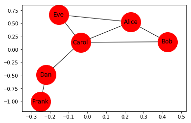

```python
G.add_node("Eve")
G.add_edge("Eve","Alice")
G.add_edge("Eve","Carol")

G.add_node("Frank")
G.add_edge("Frank","Dan")

nx.draw_networkx(G, node_size = 1600)
```

Dieses soziale Netzwerk ist nun schon hinreichend komplex, um daran unterschiedliche Darstellungsarten auszuprobieren. Bisher waren die Positionen der Knoten in der Grafik dem Zufall überlassen. Man kann sie aber auch mit so genannten "Layouts" arrangieren. Die Knoten werden dann nach bestimmten Regeln angeordnet, was spezielle Netzwerkeigenschaften verdeutlichen kann, oder einfach nur die Netzwerke generell übersichtlicher gestaltet.

### Das Spring-Layout

Eines der übersichtlichsten Layouts (und deswegen auch die Standardeinstellung in NetworkX) ist das Spring-Layout. Es heißt so, weil die Verbindungslinien als Federn (*springs*) interpretiert werden, was zur Folge hat, dass zwei verbundene Knoten, die sich zu nahe sind, vom Algorithmus, der das Netzwerk generiert, auseinander gezogen werden, und wenn sie zu weit voneinander entfernt sind, zusammengezogen werden. Zumeist liefert dies ein recht übersichtliches Bild.

Layouts werden innerhalb des `draw`-Befehls mit dem Argument `pos` definiert (Merke: wir haben das Netzwerk `G` oben bereits in all seinen Bestandteilen definiert und brauchen es deshalb in Folge nur mehr in seinen unterschiedlichen Layouts aufzurufen):

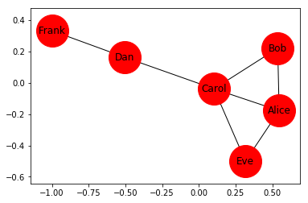

```python
# nx.spring_layout(G) errechnet das Springlayout für das Netzwerk
nx.draw_networkx(G, node_size = 1600, pos = nx.spring_layout(G))
```

### Das Random-Layout

Etwas weniger übersichtlich ist das Layout "random". Hier werden die Positionen der Knoten absolut zufällig gewählt, was dazu führt, dass die Verbindungslinien kreuz und quer laufen können. Der Vorteil dieses Layouts ist aber, dass es kaum Rechenzeit benötigt und somit gern bei großen Netzwerken benutzt wird, bei denen man den einzelnen Verbindungslinien ohnehin nur schwer folgen kann.

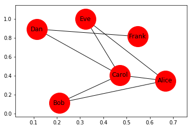

```python
nx.draw_networkx(G, node_size = 1600, pos = nx.random_layout(G))
```

### Das Circular-Layout

Beim Circular-Layout werden alle Knoten in einem Kreis angeordnet. Hier liegt der Vorteil darin, schnell erkennen zu können, wer mit wem verbunden ist.

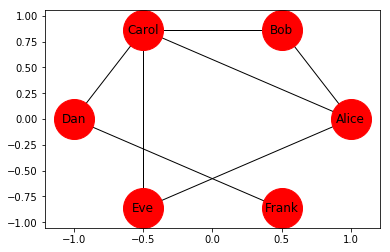

```python
nx.draw_networkx(G, node_size = 1600, pos = nx.circular_layout(G))
```

### Netzwerkanalyse

Was lässt sich nun mit einem solchen Netzwerk machen? Zunächst könnten wir versuchen, bestimmte Netzwerkeigenschaften festzustellen. Für unser soziales Netzwerk könnten wir zum Beispiel herausfinden, wie die Freundschaften im Netzwerk verteilt sind. Wir wollen also wissen, wie viele Verbindungslinien die einzelnen Knoten haben. Im Englischen spricht man hierbei vom **degree** eines Knoten. Wir erhalten diese Information mit dem Befehl `nx.degree(G)`:

```python
nx.degree(G)
```

```
DegreeView({'Alice': 3, 'Bob': 2, 'Carol': 4, 'Dan': 2, 'Eve': 2, 'Frank': 1})
```

Die Antwort ist so zu lesen: Der Knoten mit dem Namen "Alice" hat degree 3 (also drei Freunde), "Bob" hat degree 2 (zwei Freunde), und so weiter.

Oft ist man aber nur an den Zahlen selbst interessiert, nicht unbedingt daran, wie die Knoten heißen. Dazu lässt sich der Befehl `.values()` wie folgt hinzufügen:

```python
list(dict(nx.degree(G)).values())
```

```
[3, 2, 4, 2, 2, 1]
```

Als Antwort ergibt sich eine Liste, die sich recht einfach in ein Histogramm verwandeln lässt:

```
Text(0,0.5,'Zahl der Personen')
```

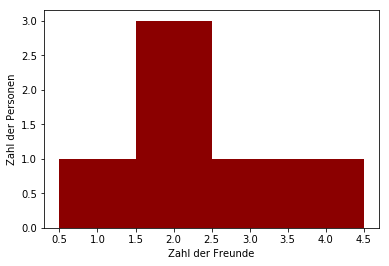

```python
plt.hist(list(dict(nx.degree(G)).values()), 4, range = (0.5, 4.5), color = "darkred")
plt.xlabel('Zahl der Freunde')
plt.ylabel('Zahl der Personen')
```

Das Histogramm zeigt, dass es drei Personen gibt, die genau zwei Freunde haben und jeweils eine Person, die einen, drei und vier Freunde hat. Richtig interessant wird eine solche Analyse erst mit großen Netzwerken mit einigen hunderten oder tausenden Knoten. Solche Netzwerke werden in der Regel nicht mehr manuell eingegeben. Es wird also nicht mehr jeder Knoten und jede Verbindung einzeln definiert, sondern ein so genannter Netzwerkgenerator verwendet.

### Netzwerkgeneratoren

Netzwerkgeneratoren eignen sich insbesondere dazu, bestimmte Archetypen von Netzwerken zu erstellen, die in der Natur, aber auch in der Gesellschaft oder in technischen Zusammenhängen immer wieder auftreten. Diese Archetypen zeichnen sich durch ganz bestimmte Netzwerktopologien aus, die in verschiedensten Kontexten in ähnlicher Weise auftreten.

### Das Small-World Netzwerk

Einer der verbreitetsten Netzwerk-Archetypen ist das so genannte Small-World-Netzwerk, das seinen Namen einem berühmt gewordenen Experiment von Stanley Milgram verdankt (siehe: http://systems-sciences.uni-graz.at/etextbook/networks/networks_2.html). Es zeichnet sich durch relativ geringe durchschnittliche Vernetzungsdichte aus, die allerdings von Regionen hoher Vernetzungsdichte unterbrochen ist, wobei diese Regionen ihrerseits über kurze Pfade mit anderen solchen dichten Regionen verbunden sind. Die meisten Knoten in solchen Netzwerken haben nur recht wenige Verbindungen. Einige wenige haben dagegen viele und ganz wenige Knoten haben sehr viele Verbindungen. Diese sehr wenigen, überaus gut vernetzten Knoten werden als **Hubs** bezeichnet. Viele soziale Netzwerke, aber auch das Internet oder viele Gen-Netzwerke haben diese Small-World-Struktur.

Der Python-Befehl zum Erzeugen solcher Netzwerke ist ein wenig sperrig. Die Namen der Entwickler des Algorithmus zur Generierung dieses Netzwerktyps findet in ihm Platz: `connected_watts_strogatz_graph`. Als Argumente braucht dieser Generator die Anzahl der Knoten im Netzwerk, die mittlere Anzahl der Verbindungen pro Knoten, und eine Zahl, die festlegt wie groß die Hubs werden dürfen, die entstehen.

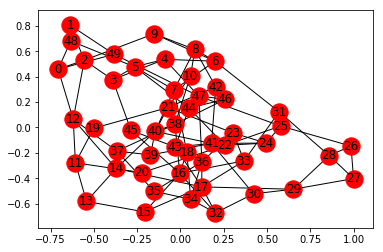

```python
# erzeugt ein Small-world-Netzwerk mit 50 Knoten, und durchschnittlich 5 Verbindungen pro Knoten
# die dritte Zahl gibt die Chance an, dass ein Knoten mit einem seiner Verbindungen an einen Hub andockt.
G = nx.connected_watts_strogatz_graph(50, 5, 0.40)
nx.draw_networkx(G)
```

Durch die Größe des Netzwerks ist die Darstellung nun ein wenig unübersichtlich geworden, und wir können nicht mehr ganz klar erkennen, wer mit wem verbunden ist, bzw. welcher Knoten viele Verbindungen hat und welcher wenige. Übersichtlicher könnte dies werden, wenn wir die Größe der Knoten in der Darstellung davon abhängig machen, welchen `degree` sie haben:

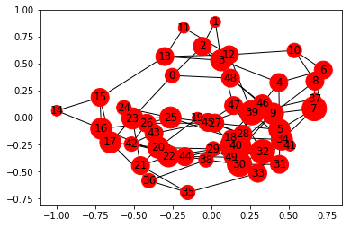

```python
import networkx as nx
import matplotlib.pyplot as plt
%matplotlib inline

G = nx.connected_watts_strogatz_graph(50, 5, 0.40)
deg = dict(nx.degree(G)).values()
size = [] # leere Liste wird angelegt

# für jeden Wert in der Degreeliste wird ein Eintrag in die Sizeliste angefügt
for wert in deg:
    size.append(50 * wert**1.5)

nx.draw_networkx(G, node_size = size)
```

Nun sieht man anhand der Größe der Knoten, dass einige Knoten deutlich mehr Verbindungen haben als andere. Diese Hubs des Netzwerks können großen Einfluss auf das Gesamtsystem haben.

### Das hierarchische Netzwerk

In hierarchischen Netzwerken hat zumeist nur ein Knoten eine besondere Stellung. Dieser zentralste Konten steht in Verbindung zu weniger wichtigen Knoten, die ihrerseits in Verbindung zu weiteren, noch weniger zentralen Knoten stehen.

Solche hierarchischen Strukturen finden sich vielfach in Organisiationen, aber auch zum Beispiel in Nahrungsketten im Tierreich. Der NetworkX-Befehl zum Erstellen von hierarchischen Netzwerken lautet `balanced_tree`. Als Argumente werden die Anzahl der Knoten-Verbindungen in die jeweils untere Ebene der Hierarchie und die Zahl der Ebenen benötigt.

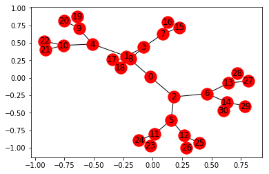

```python
import networkx as nx
import matplotlib.pyplot as plt
%matplotlib inline

# ein hierarchisches Netzwerk mit 2 Verbindungen "nach unten" und 4 Ebenen
G = nx.balanced_tree(2, 4)
nx.draw_networkx(G)
```

Besonders übersichtlich wird die Darstellung eines hirarchischen Netzwerks mit speziellem Layout. Da der genaue Aufbau der Funktion für dieses Layout den Rahmen dieses Kapitels sprengt, behandeln wir ihn im Folgenden als "Blackbox". Das heißt, wir zeigen die Funktion und ihren Output im Folgenden, erklären aber nicht wie sie genau funktioniert.

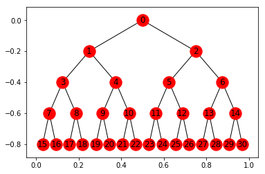

```python
import networkx as nx
import matplotlib.pyplot as plt
%matplotlib inline

#BLACKBOXFUNKTION, die man nicht verstehen muss
def hierarchy_pos(G, root, width=1., vert_gap = 0.2, vert_loc = 0, xcenter = 0.5,
                  pos = None, parent = None):
    if pos == None:
        pos = {root:(xcenter,vert_loc)}
    else:
        pos[root] = (xcenter, vert_loc)
    neighbors = list(G.neighbors(root))
    if parent != None:
        neighbors.remove(parent)
    if len(neighbors) != 0:
        dx = width/len(neighbors)
        nextx = xcenter - width/2 - dx/2
        for neighbor in neighbors:
            nextx += dx
            pos = hierarchy_pos(G,neighbor, width = dx, vert_gap = vert_gap,
                                vert_loc = vert_loc-vert_gap, xcenter = nextx, pos = pos,
                                parent = root)
    return pos
# ENDE DER BLACKBOXFUNTKION

G=nx.balanced_tree(2, 4)
nx.draw_networkx(G, pos = hierarchy_pos(G, 0))
```

### Das Grid-Netzwerk

Auch eine einfache Gitterstruktur (Grid) lässt sich als Netzwerk betrachten. Solche Strukturen treten zum Beispiel in Kristallen auf, aber auch überall sonst, wo Objekte bevorzugt mit ihren nächsten Nachbarn interagieren.

Der Befehl zum Erstellen von Grid-Netzwerken lautet `grid_2d_graph` und braucht als Argumente die Länge und die Breite des Gitters.

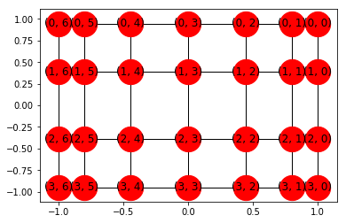

```python
import networkx as nx
import matplotlib.pyplot as plt
%matplotlib inline

G = nx.grid_2d_graph(4, 7) # erzeugt ein 4 mal 7 Grid
# Spectral-layout für passende Grid-Form
nx.draw_networkx(G,pos = nx.spectral_layout(G), node_size = 800)
```

### Das Caveman-Netzwerk

Ein so genanntes Caveman-Netzwerk zeichnet sich durch mehrere dichter vernetzte Knoten-Gruppen aus, so genannte **Cluster**, die untereinander nur wenig miteinander verbunden sind.

Der Befehl zum erzeugen solcher Netzwerke lautet `connected_caveman_graph` und benötigt als Argumente die Zahl der Cluster und die Größe der Cluster.

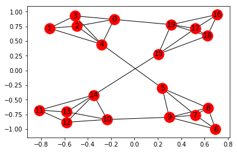

```python
import networkx as nx
import matplotlib.pyplot as plt
%matplotlib inline

G=nx.connected_caveman_graph(4, 5)  # Netzwerk aus 4 Clustern mit je 5 Knoten
nx.draw_networkx(G)
```